# NYCFlights: Arrival Delay Logictic Model

# Loading the necessary libraries

```
## data.table + dplyr code now lives in dtplyr.
## Please library(dtplyr)!
```

## Logsitic and Inverse Logistic Transformation

- Write an R function for the logistic function. The function should accept a `numeric` vector with values `[-Inf,Inf]` and produce a numeric vector in the the range `[0,1]`.

```r
sample_fun=function(x){
  y=1/(1+exp(-x))
  return(y)
}

sample_fun(c(-10:10))
```

```
##  [1] 4.539787e-05 1.233946e-04 3.353501e-04 9.110512e-04 2.472623e-03
##  [6] 6.692851e-03 1.798621e-02 4.742587e-02 1.192029e-01 2.689414e-01
## [11] 5.000000e-01 7.310586e-01 8.807971e-01 9.525741e-01 9.820138e-01
## [16] 9.933071e-01 9.975274e-01 9.990889e-01 9.996646e-01 9.998766e-01
## [21] 9.999546e-01
```

- Plot the logistic function from `[-10,10]`

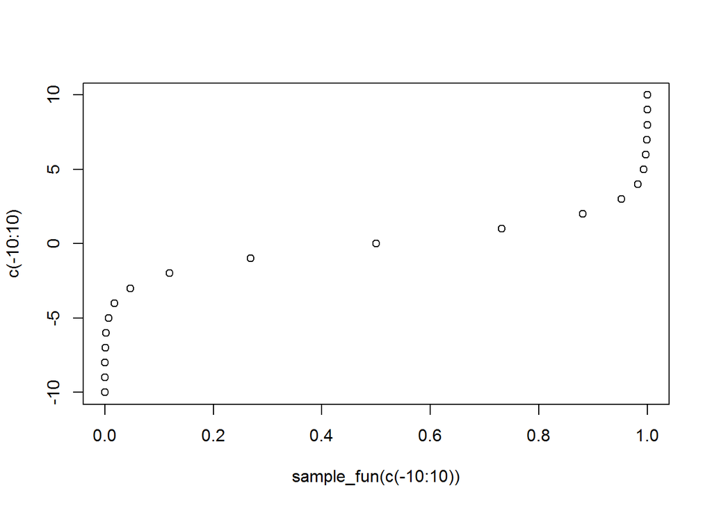

```r
plot(sample_fun(c(-10:10)),c(-10:10))
```

- Write a R function for the inverse logistic function. The function should accept a `numeric` vector with values `[0,1]` and prodcuce a numeric vector in the range `[-Inf,Inf]`

```r
inv_log=function(x){
  y=log(x/(1-x))
  return(y)
}

inv_log(c(0:1))
```

```
## [1] -Inf  Inf
```

- Plot the Inverse Logistic function from `[0,1]`

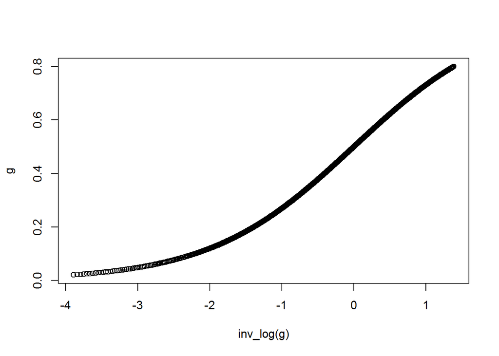

```r
g=seq(.02,.8,.001)

plot(inv_log(g),g)
```

**Hint:** For plotting curves see `?graphics::curve` or `?ggplot2::stat_function`

# NYCFlights Model

Using the rectangular data that you created from the earlier assignment and following theexample from the text and class, create a model for arr_delay >= 22 minutes. Describe/Explain each of the steps and show all work.

# Step 1

[output not shown]

KNIT YOUR DOCUMENT AS *HTML* AND SUBMIT IT AND THE `Rmd` file to your repository.

```r
Aviation_new=mutate(Aviation,arr_delay_22=ifelse(arr_delay>22,0,1))
```

# Step 2

# Selecting the required variables

```r
Aviation1=Aviation_new[, c("arr_delay","arr_delay_22", "visib","precip","humid","temp","dep_delay","arr_time","carrier","origin","dest","air_time","sched_arr_time","month","distance")]
```

# Plotting the graph to understnad the skewness

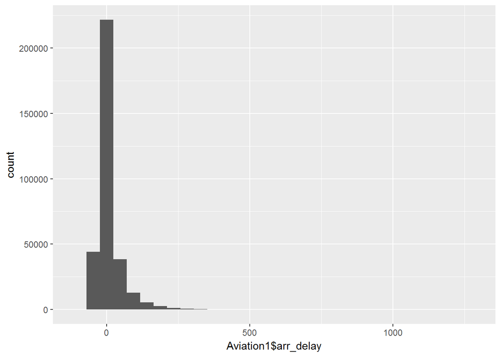

```r
qplot(Aviation1$arr_delay)
```

# Find the corelation matrics

```r
numeric_column=Aviation1 %>% sapply(is.numeric) %>%  which() %>% names()
Aviation1[,numeric_column,] %>% cor(use="pairwise.complete.obs")
```

```
##                  arr_delay arr_delay_22        visib       precip
## arr_delay       1.00000000  -0.73974095 -0.142435360  0.068343055
## arr_delay_22   -0.73974095   1.00000000  0.135084398 -0.070736538
## visib          -0.14243536   0.13508440  1.000000000 -0.315346736
## precip          0.06834306  -0.07073654 -0.315346736  1.000000000
## humid           0.08054219  -0.06455888 -0.530599373  0.204853771
## temp            0.06138370  -0.06486015  0.067804076 -0.010308892
## dep_delay       0.91480276  -0.65300421 -0.122013170  0.060467735
## arr_time        0.02448214  -0.08426837  0.025910093 -0.014684711
## air_time       -0.03529709   0.01165511 -0.020569258  0.011374854
## sched_arr_time  0.13326129  -0.15507200  0.013351713 -0.007290760
## month          -0.01738202   0.01640204  0.040789514 -0.006946121
## distance       -0.06186776   0.03322622 -0.001810749  0.004952601
##                      humid        temp   dep_delay     arr_time
## arr_delay       0.08054219  0.06138370  0.91480276  0.024482143
## arr_delay_22   -0.06455888 -0.06486015 -0.65300421 -0.084268370
## visib          -0.53059937  0.06780408 -0.12201317  0.025910093
## precip          0.20485377 -0.01030889  0.06046773 -0.014684711
## humid           1.00000000  0.04901764  0.05813340 -0.337382416
## temp            0.04901764  1.00000000  0.09024621  0.124910381
## dep_delay       0.05813340  0.09024621  1.00000000  0.028728803
## arr_time       -0.33738242  0.12491038  0.02872880  1.000000000
## air_time        0.03327170 -0.03243153 -0.02240508  0.054296029
## sched_arr_time -0.35165906  0.15661501  0.16048849  0.788997062
## month           0.05553529  0.25889282 -0.02005702 -0.002519931
## distance        0.02996917  0.01176668 -0.02167079  0.046991243
##                   air_time sched_arr_time        month     distance
## arr_delay      -0.03529709    0.133261288 -0.017382024 -0.061867756
## arr_delay_22    0.01165511   -0.155071995  0.016402042  0.033226219
## visib          -0.02056926    0.013351713  0.040789514 -0.001810749
## precip          0.01137485   -0.007290760 -0.006946121  0.004952601
## humid           0.03327170   -0.351659062  0.055535290  0.029969165
## temp           -0.03243153    0.156615007  0.258892823  0.011766678
## dep_delay      -0.02240508    0.160488489 -0.020057020 -0.021670789
## arr_time        0.05429603    0.788997062 -0.002519931  0.046991243
## air_time        1.00000000    0.078918301  0.010924168  0.990649647
## sched_arr_time  0.07891830    1.000000000 -0.004172739  0.068725917
## month           0.01092417   -0.004172739  1.000000000  0.021635648
## distance        0.99064965    0.068725917  0.021635648  1.000000000
```

# Step 3

Splitting the data in to testing and training set

```r
set.seed(1000)

split=sample.split(Aviation1$arr_delay_22,SplitRatio = .65)
train=subset(Aviation1,split==TRUE)
test=subset(Aviation1,split==FALSE)
```

# Step 4

Applying the log4istic function

```r
Aviation1_Log=glm(arr_delay_22 ~ dep_delay+carrier+air_time+visib+precip+temp+humid ,data=train,family = binomial)
summary(Aviation1_Log)
```

```
##
## Call:
## glm(formula = arr_delay_22 ~ dep_delay + carrier + air_time +
##     visib + precip + temp + humid, family = binomial, data = train)
##
## Deviance Residuals:
##     Min       1Q   Median       3Q      Max
## -3.7836   0.1797   0.2423   0.3219   3.4481
##
## Coefficients:
##               Estimate Std. Error  z value Pr(>|z|)
## (Intercept)  2.9728563  0.0832775   35.698  < 2e-16 ***
## dep_delay   -0.1053085  0.0005526 -190.553  < 2e-16 ***
## carrierAA    0.0480204  0.0543515    0.884  0.37696
## carrierAS    0.7148296  0.2509373    2.849  0.00439 **
## carrierB6   -0.2782458  0.0484073   -5.748 9.03e-09 ***
## carrierDL    0.1413745  0.0509576    2.774  0.00553 **
## carrierEV   -0.3566163  0.0482180   -7.396 1.40e-13 ***
## carrierF9   -0.6605486  0.1594478   -4.143 3.43e-05 ***
## carrierFL   -0.8393328  0.0878260   -9.557  < 2e-16 ***
## carrierHA    1.9063503  0.4335977    4.397 1.10e-05 ***
## carrierMQ   -0.7967788  0.0527025  -15.118  < 2e-16 ***
## carrierOO   -1.6195812  0.8622987   -1.878  0.06035 .
## carrierUA    0.2509739  0.0501402    5.005 5.57e-07 ***
## carrierUS   -0.5957485  0.0570553  -10.442  < 2e-16 ***
## carrierVX    0.8244351  0.0955228    8.631  < 2e-16 ***
## carrierWN    0.2960805  0.0633884    4.671 3.00e-06 ***
## carrierYV   -0.4507949  0.2306782   -1.954  0.05068 .
## air_time    -0.0028983  0.0001144  -25.342  < 2e-16 ***
## visib        0.0798562  0.0046793   17.066  < 2e-16 ***
## precip      -1.2277655  0.3763061   -3.263  0.00110 **
## temp         0.0003915  0.0005030    0.778  0.43638
## humid       -0.0025269  0.0005571   -4.536 5.74e-06 ***
## ---
## Signif. codes:  0 '***' 0.001 '**' 0.01 '*' 0.05 '.' 0.1 ' ' 1
##
## (Dispersion parameter for binomial family taken to be 1)
##
##     Null deviance: 208183  on 212002  degrees of freedom
## Residual deviance:  89460  on 211981  degrees of freedom
##   (772 observations deleted due to missingness)
## AIC: 89504
##
## Number of Fisher Scoring iterations: 7
```